# Damages due to Storm Events in the United States

Hilary Condon

May 21, 2016

# Synopsis

This report analyzes the impact of severe weather events in the United States in terms of public and economic health.

The raw data for this analysis is from the U.S. National Oceanic and Atmospheric Administration (NOAA) Storm Database.

The data for this assignment come in the form of a comma-separated-value file compressed via the bzip2 algorithm to reduce its size. You can download the file from [the course web site:](http://d396qusza40orc.cloudfront.net/repdata%2Fdata%2FStormData.csv.bz2)

There is also some documentation of the database available. Here you will find how some of the variables are constructed/defined. * National Weather Service [Storm Data Documentation](https://d396qusza40orc.cloudfront.net/repdata%2Fpeer2_doc%2Fpd01016005curr.pdf) * National Climatic Data Center Storm Events [FAQ](https://d396qusza40orc.cloudfront.net/repdata%2Fpeer2_doc%2FNCDC%20Storm%20Events-FAQ%20Page.pdf)

Per the below results, this report finds that Tornados and Excessive Heat are the most damaging weather events in terms of public health. Hurricanes, Floods, and Droughts were found to have the greatest economic cost in terms of property and crop damage.

## This analysis seeks to answer the following questions:

#### 1. Across the United States, which types of events are most harmful with respect to population health?

#### 2. Across the United States, which types of events have the greatest economic consequences?

# Initial Setup

Prior to loading and processing the data, we will first set some global options and load in data packages as necessary for our subsequent analysis.

```r
echo = TRUE #Always make code visible
```

# Loading and Processing the Raw Data

The dataset contains records of major storms and weather events in the United States from 1950 - November 2011.

First, we will download the compressed data file from the link provided on the Coursera assignment page.

We will then uncompress the dataset while reading it into R to variable “stormData”.

The dataset is large, so this code chunk will be created with cache = TRUE.

```r
#Download data and read it into R, if this has not already occurred.

## Assign FileURL to path to zipped data-

if(!file.exists("./data/stormData.csv.bz2")) {
        fileURL <- "http://d396qusza40orc.cloudfront.net/repdata%2Fdata%2FStormData.csv.bz2"
        download.file(fileURL,dest = "data/stormData.csv.bz2", method = "curl")
}

stormData <- read.csv(bzfile("./data/stormData.csv.bz2"),
                     header=TRUE,
                     sep=",",
                     stringsAsFactors=FALSE)
```

We will do a basic, preliminary review of the data set, where we review the dimensions and check out the first couple of rows.

```r
## Review the Data Dimensions
dimensions <- dim(stormData)

## Display the first 2 rows of data from the dataset.
head(stormData, n = 2)
```

```
##   STATE__          BGN_DATE BGN_TIME TIME_ZONE COUNTY COUNTYNAME STATE
## 1       1 4/18/1950 0:00:00     0130       CST     97     MOBILE    AL
## 2       1 4/18/1950 0:00:00     0145       CST      3    BALDWIN    AL
##    EVTYPE BGN_RANGE BGN_AZI BGN_LOCATI END_DATE END_TIME COUNTY_END
## 1 TORNADO         0                                               0
## 2 TORNADO         0                                               0
##   COUNTYENDN END_RANGE END_AZI END_LOCATI LENGTH WIDTH F MAG FATALITIES
## 1         NA         0                        14   100 3   0          0
## 2         NA         0                         2   150 2   0          0
##   INJURIES PROPDMG PROPDMGEXP CROPDMG CROPDMGEXP WFO STATEOFFIC ZONENAMES
## 1       15    25.0          K       0
## 2        0     2.5          K       0
##   LATITUDE LONGITUDE LATITUDE_E LONGITUDE_ REMARKS REFNUM
## 1     3040      8812       3051       8806              1
## 2     3042      8755          0          0              2
```

The data set contains 902297 events and 37 variables.

### The following variables are of interest for our analysis:

**EVTYPE**

We will analyize the data to try to answer the following questions: 1. Across the United States, which types of events are most harmful with respect to population health? 2. Across the United States, which types of events have the greatest economic consequences?

There are 48 event types defined in the NOAA Storm Data Documentation, which we will store in variable validName -

```r
validName <- c("Astronomical Low Tide", "Avalanche", "Blizzard", "Coastal Flood", "Cold/Wind Chill", "Debris Flow", "Dense Fog", "Dense Smoke", "Drought", "Dust Devil", "Dust Storm", "Excessive Heat", "Extreme Cold/Wind Chill", "Flash Flood", "Flood", "Frost/Freeze", "Funnel Cloud", "Freezing Fog", "Hail", "Heat", "Heavy Rain", "Heavy Snow", "High Surf", "High Wind", "Hurricane (Typhoon)", "Ice Storm", "Lake-Effect Snow", "Lakeshore Flood", "Lightning", "Marine Hail", "Marine High Wind", "Marine Strong Wind", "Marine Thunderstorm Wind", "Rip Current", "Seiche", "Sleet", "Storm Surge/Tide", "Strong Wind", "Thunderstorm Wind", "Tornado", "Tropical Depression", "Tropical Storm", "Tsunami", "Volcanic Ash", "Waterspout", "Wildfire", "Winter Storm", "Winter Weather")
validName <- toupper(validName)

uniqueEvents <- unique(stormData$EVTYPE)
uniqueEvents <- toupper(uniqueEvents)
length(uniqueEvents)
```

```
## [1] 985
```

If we review the unique event names stored in the data set, we see that there are a total of 985 events in the dataset. This is a fair number more than the 48 provided.

We do some initial cleaning of the data set to convert all of the records for this variable to upper case, remove trailing and leading white space around strings.

We will also use regular expression substitutions to try to somewhat normalize the expressions stored for this variable.

```r
stormDataProcessed <- stormData
dim(stormDataProcessed)
```

```
## [1] 902297     37
```

```r
##CONVERT TO UPPER
stormDataProcessed$EVTYPE <- toupper(stormDataProcessed$EVTYPE)

## Clean Data Event Types by Removing Trailing / Leading Spaces
stormDataProcessed$EVTYPE <- gsub("^\\s+|\\s+$", "", stormDataProcessed$EVTYPE)

## Use Regular Expression Substitution to Clean Event Type Data Set
stormDataProcessed$EVTYPE <- gsub("TSTM|THUNDERSTORMS?", "THUNDERSTORM", stormDataProcessed$EVTYPE)
stormDataProcessed$EVTYPE <- gsub("^(EXTREME|RECORD/EXCESSIVE|RECORD) HEAT$", "EXCESSIVE HEAT", stormDataProcessed$EVTYPE)
stormDataProcessed$EVTYPE <- gsub("^TORNADO.*", "TORNADO", stormDataProcessed$EVTYPE)
stormDataProcessed$EVTYPE <- gsub("^TROPICAL STORM.*", "TROPICAL STORM", stormDataProcessed$EVTYPE)
stormDataProcessed$EVTYPE <- gsub("^WINTER STORM.*", "WINTER STORM", stormDataProcessed$EVTYPE)
stormDataProcessed$EVTYPE <- gsub("^THUNDERSNOW$|^ICE STORM.*", "ICE STORM", stormDataProcessed$EVTYPE)
stormDataProcessed$EVTYPE <- gsub("^COASTAL FLOOD.*", "COASTAL FLOOD", stormDataProcessed$EVTYPE)
stormDataProcessed$EVTYPE <- gsub("^(GROUND)? ?BLIZZARD.*$", "BLIZZARD", stormDataProcessed$EVTYPE)
stormDataProcessed$EVTYPE <- gsub("^DUST STORM.*$", "DUST STORM", stormDataProcessed$EVTYPE)
stormDataProcessed$EVTYPE <- gsub("^ASTRONOMICAL HIGH TIDE$", "STORM SURGE/TIDE", stormDataProcessed$EVTYPE)
stormDataProcessed$EVTYPE <- gsub("^TYPHOON", "HURRICANE (TYPHOON)", stormDataProcessed$EVTYPE)
stormDataProcessed$EVTYPE <- gsub("WAVES?|SWELLS?", "SURF", stormDataProcessed$EVTYPE)
stormDataProcessed$EVTYPE <- gsub("^LIGHTNING.*", "LIGHTNING", stormDataProcessed$EVTYPE)
stormDataProcessed$EVTYPE <- gsub("STORMS?", "STORM", stormDataProcessed$EVTYPE)
stormDataProcessed$EVTYPE <- gsub("^(SMALL )?HAIL.*", "HAIL", stormDataProcessed$EVTYPE)
stormDataProcessed$EVTYPE <- gsub("^TH?UN?DEE?RS?TO?RO?M ?WIND.*|^(SEVERE )?THUNDERSTORM$|^WIND STORM$|^(DRY )?MI[CR][CR]OBURST.*|^THUNDERSTORMW$", "THUNDERSTORM WIND", stormDataProcessed$EVTYPE)
stormDataProcessed$EVTYPE <- gsub("^FLOODS?.*|^URBAN/SML STREAM FLD$|^(RIVER|TIDAL|MAJOR|URBAN|MINOR|ICE JAM|RIVER AND STREAM|URBAN/SMALL STREAM)? FLOOD(ING)?S?$|^HIGH WATER$|^URBAN AND SMALL STREAM FLOODIN$|^DROWNING$|^DAM BREAK$", "FLOOD", stormDataProcessed$EVTYPE)
stormDataProcessed$EVTYPE <- gsub("WEATHER/MIX", "WEATHER", stormDataProcessed$EVTYPE)
stormDataProcessed$EVTYPE <- gsub("^WILD/FOREST FIRE$|^(WILD|BRUSH|FOREST)? ?FIRES?$", "WILDFIRE", stormDataProcessed$EVTYPE)
stormDataProcessed$EVTYPE <- gsub("^(GUSTY|NON-SEVERE|NON ?-?THUNDERSTORM)? ?WIND.*|^ICE/STRONG WIND$", "STRONG WIND", stormDataProcessed$EVTYPE)
stormDataProcessed$EVTYPE <- gsub("^HURRICANE.*", "HURRICANE (TYPHOON)", stormDataProcessed$EVTYPE)
stormDataProcessed$EVTYPE <- gsub("^WHIRLWIND$|^GUSTNADO$|^TORNDAO$", "TORNADO", stormDataProcessed$EVTYPE)
stormDataProcessed$EVTYPE <- gsub(".*SUMMARY OF.*", "", stormDataProcessed$EVTYPE)
stormDataProcessed$EVTYPE <- gsub(".*LANDSLIDE.*", "DEBRIS FLOW", stormDataProcessed$EVTYPE)
stormDataProcessed$EVTYPE <- gsub(".*SUMMARY.*", "", stormDataProcessed$EVTYPE)
stormDataProcessed$EVTYPE <- gsub(".*GUSTY.*", "", stormDataProcessed$EVTYPE)
stormDataProcessed$EVTYPE <- gsub(".*DEVEL.*", "DUST DEVIL", stormDataProcessed$EVTYPE)
stormDataProcessed$EVTYPE <- gsub(".*Wind.*", "WIND", stormDataProcessed$EVTYPE)
stormDataProcessed$EVTYPE <- gsub(".*Coastal Flooding.*", "COASTAL FLOOD", stormDataProcessed$EVTYPE)
stormDataProcessed$EVTYPE <- gsub("^HEAT/DROUGHT", "DROUGHT", stormDataProcessed$EVTYPE)
stormDataProcessed$EVTYPE <- gsub("CSTL", "COASTAL", stormDataProcessed$EVTYPE)
stormDataProcessed$EVTYPE <- gsub("COASTALFLOOD", "COASTAL FLOOD", stormDataProcessed$EVTYPE)
stormDataProcessed$EVTYPE <- gsub("DEBRIS FLOWS", "DEBRIS FLOW", stormDataProcessed$EVTYPE)
stormDataProcessed$EVTYPE <- gsub("^EROSION/CSTL FLOOD$|^COASTAL FLOOD/EROSION$|^COASTAL SURGE/TIDE$", "COASTAL FLOOD", stormDataProcessed$EVTYPE)
stormDataProcessed$EVTYPE <- gsub("^MARINE MISHAP$|^HIGH WIND/SEAS$", "MARINE HIGH WIND", stormDataProcessed$EVTYPE)
stormDataProcessed$EVTYPE <- gsub("^HIGH WIND.*", "HIGH WIND", stormDataProcessed$EVTYPE)
stormDataProcessed$EVTYPE <- gsub("^HIGH SEAS$", "MARINE STRONG WIND", stormDataProcessed$EVTYPE)
stormDataProcessed$EVTYPE <- gsub("^RIP CURRENT.*", "RIP CURRENT", stormDataProcessed$EVTYPE)
stormDataProcessed$EVTYPE <- gsub("^EXCESSIVE RAINFALL$|^RAIN.*|^TORRENTIAL RAINFALL$|^(HEAVY|HVY)? (RAIN|MIX|PRECIPITATION).*", "HEAVY RAIN", stormDataProcessed$EVTYPE)
stormDataProcessed$EVTYPE <- gsub("^WATERSPOUT.*", "WATERSPOUT", stormDataProcessed$EVTYPE)
stormDataProcessed$EVTYPE <- gsub("WINDS?|WINDS?/HAIL", "WIND", stormDataProcessed$EVTYPE)
stormDataProcessed$EVTYPE <- gsub("RAINS?", "RAIN", stormDataProcessed$EVTYPE)
stormDataProcessed$EVTYPE <- gsub("^COASTAL ?STORM$|^MARINE ACCIDENT$", "MARINE THUNDERSTORM WIND", stormDataProcessed$EVTYPE)
stormDataProcessed$EVTYPE <- gsub("^FLASH FLOOD.*|^RAPIDLY RISING WATER$", "FLASH FLOOD", stormDataProcessed$EVTYPE)
stormDataProcessed$EVTYPE <- gsub("WATERSPOUTS?", "WATERSPOUT", stormDataProcessed$EVTYPE)
stormDataProcessed$EVTYPE <- gsub("CURRENTS?", "CURRENT", stormDataProcessed$EVTYPE)
stormDataProcessed$EVTYPE <- gsub("^WINDCHILL$|^COLD.*|^LOW TEMPERATURE$|^UNSEASONABLY COLD$", "COLD/WIND CHILL", stormDataProcessed$EVTYPE)
stormDataProcessed$EVTYPE <- gsub("^EXTREME WIND ?CHILL$|^(EXTENDED|EXTREME|RECORD)? COLDS?$", "EXTREME COLD/WIND CHILL", stormDataProcessed$EVTYPE)
stormDataProcessed$EVTYPE <- gsub("^RAIN/SNOW$|^(BLOWING|HEAVY|EXCESSIVE|BLOWING|ICE AND|RECORD)? ?SNOWS?.*", "HEAVY SNOW", stormDataProcessed$EVTYPE)
stormDataProcessed$EVTYPE <- gsub("^FOG$", "DENSE FOG", stormDataProcessed$EVTYPE)
stormDataProcessed$EVTYPE <- gsub("SURGE$", "SURGE/TIDE", stormDataProcessed$EVTYPE)
stormDataProcessed$EVTYPE <- gsub("CLOUDS?", "CLOUD", stormDataProcessed$EVTYPE)
stormDataProcessed$EVTYPE <- gsub("^FROST[/\\]FREEZE$|^FROST$|^(DAMAGING)? ?FREEZE$|^HYP[OE]R?THERMIA.*|^ICE$|^(ICY|ICE) ROADS$|^BLACK ICE$|^ICE ON ROAD$", "FROST/FREEZE", stormDataProcessed$EVTYPE)
stormDataProcessed$EVTYPE <- gsub("^GLAZE.*|^FREEZING (RAIN|DRIZZLE|RAIN/SNOW|SPRAY$)$|^WINTRY MIX$|^MIXED PRECIP(ITATION)?$|^WINTER WEATHER MIX$|^LIGHT SNOW$|^FALLING SNOW/ICE$|^SLEET.*", "SLEET", stormDataProcessed$EVTYPE)
stormDataProcessed$EVTYPE <- gsub("^HEAT WAVES?$|^UNSEASONABLY WARM$|^WARM WEATHER$", "HEAT", stormDataProcessed$EVTYPE)
stormDataProcessed$EVTYPE <- gsub("^HEAVY SURF(/HIGH SURF)?.*$|^(ROUGH|HEAVY) SEAS?.*|^(ROUGH|ROGUE|HAZARDOUS) SURF.*|^HIGH WIND AND SEAS$|^HIGH SURF.*", "HIGH SURF", stormDataProcessed$EVTYPE)
stormDataProcessed$EVTYPE <- gsub("^UNSEASONABLY WARM AND DRY$|^DROUGHT.*|^HEAT WAVE DROUGHT$", "DROUGHT", stormDataProcessed$EVTYPE)


uniqueEventsProcessed<- unique(stormDataProcessed$EVTYPE)
length(uniqueEventsProcessed)
```

```
## [1] 324
```

Following the above data cleaning, there are now 324 unique values for this variable.

```r
##Create Subset of Data where the EVTYPE variable Names are in the validName list of permitted values
stormDataProcessedSub <- stormDataProcessed[stormDataProcessed$EVTYPE %in% validName,]

##Review the dimensions to confirm that the majority of the data set is still present:
dim(stormDataProcessedSub)
```

```
## [1] 900867     37
```

**BGN_DATE**

Events can occur over a series of days, but for the purposes of our analysis, we are not concerned with event duration. Accordingly, the variable BGN_DATE should meet our need to determine the year in which an event occured.

This variable is required for our analysis, as we will need to subset the data to review records from 1995 - 2011.

While the data set contains records from the 1950s - 2011, many of the historical records are significantly less complete than more recent records.

As part of our data processing, we will convert the values for this variable to date values using the lubridate package.

```r
##Subset data to include records from 1995 - 2011

stormDataProcessedSub <- stormDataProcessedSub %>%
        filter(year(mdy_hms(BGN_DATE)) >= 1995)
dim(stormDataProcessedSub)
```

```
## [1] 680223     37
```

**FATALITIES and INJURIES**

These variables will be used to evaluate how harmful events are with respect to population health.

** PROPDMG, PRMPDMGEXP, CROPDMG, and CROPDMGEXP**

The PROPDMG and CROPDMG will be used to evalate the economic cost caused by the various event types.

The PROPDMGEXP and CROPDMGEXP variables will be used to convert the values stored for the PROPDMG and CROPDMG to a million dollar base so that the data is consistent and can be compared.

```r
## Create Helper Function to Normalize Permitted Values to Millions of Dollars or Set to NA
normalizeExp <- function(expSym) {
        if(toupper(expSym)== "B") exp <- 1000
        else if (toupper(expSym)=="M") exp <- 1
        else if (toupper(expSym)=="K") exp <- 1/1000
        else if (toupper(expSym) == "H") exp <- 1/10000
        else exp <- 0
        return(exp)
}

## Create Call to Function with Vectorize
returnExpVector <- Vectorize(normalizeExp)
```

### After the above steps are complete, we can do the final processing below to create our final data set.

```r
stormDataFinal <- stormDataProcessedSub %>%
        mutate(PropertyDamageExp = returnExpVector(PROPDMGEXP),
               CropDamageExp = returnExpVector(CROPDMGEXP),
               EventYear = year(mdy_hms(BGN_DATE)),
               PropertyDamage = PROPDMG * PropertyDamageExp,
               CropDamage = CROPDMG * CropDamageExp) %>%
        select(EventYear, EventType = EVTYPE, Fatalities = FATALITIES, Injuries = INJURIES, PropertyDamage, CropDamage)

## Group Data for Plotting
plotData <- stormDataFinal %>% group_by(EventType) %>%
        summarize(TotalFatalities = sum(Fatalities),
                  TotalInjuries=sum(Injuries),
                  TotalPropertyDamage = sum(PropertyDamage),
                  TotalCropDamage = sum(CropDamage))

summary(stormDataFinal)
```

```
##    EventYear     EventType           Fatalities          Injuries
##  Min.   :1995   Length:680223      Min.   :  0.0000   Min.   :0.00e+00
##  1st Qu.:2000   Class :character   1st Qu.:  0.0000   1st Qu.:0.00e+00
##  Median :2004   Mode  :character   Median :  0.0000   Median :0.00e+00
##  Mean   :2004                      Mean   :  0.0148   Mean   :9.12e-02
##  3rd Qu.:2008                      3rd Qu.:  0.0000   3rd Qu.:0.00e+00
##  Max.   :2011                      Max.   :583.0000   Max.   :1.15e+03
##  PropertyDamage       CropDamage
##  Min.   :0.00e+00   Min.   :   0.000
##  1st Qu.:0.00e+00   1st Qu.:   0.000
##  Median :0.00e+00   Median :   0.000
##  Mean   :5.50e-01   Mean   :   0.055
##  3rd Qu.:0.00e+00   3rd Qu.:   0.000
##  Max.   :1.15e+05   Max.   :1510.000
```

```r
dim(stormDataFinal)
```

```
## [1] 680223      6
```

# Results

## 1. Determine which types of events are most harmful with respect to population health.

The top 10 most damaging events for human health in terms of their likelihood to cause death and injury are below:

** Top Ten Most Likely Events to Result in Loss of Life **

```r
fatal <- aggregate(plotData[, 2],by =list(plotData$EventType), FUN = "sum")
fatal <- arrange(fatal, desc(TotalFatalities), Group.1)
colnames(fatal)<-c("EventType", "TotalFatalities")
head(fatal, n=10)
```

```
##                  EventType TotalFatalities
## 1           EXCESSIVE HEAT            1996
## 2                  TORNADO            1546
## 3              FLASH FLOOD             942
## 4                     HEAT             935
## 5                LIGHTNING             730
## 6              RIP CURRENT             569
## 7                    FLOOD             471
## 8        THUNDERSTORM WIND             424
## 9  EXTREME COLD/WIND CHILL             271
## 10               HIGH WIND             252
```

** Top Ten Most Likely Events to Result in Human Injury **

```r
injury <- aggregate(plotData[, 3],by =list(plotData$EventType), FUN = "sum")
injury <- arrange(injury, desc(TotalInjuries), Group.1)
colnames(injury)<-c("EventType", "TotalInjuries")
head(injury, n=10)
```

```
##              EventType TotalInjuries
## 1              TORNADO         21783
## 2                FLOOD          6855
## 3       EXCESSIVE HEAT          6680
## 4    THUNDERSTORM WIND          5670
## 5            LIGHTNING          4633
## 6                 HEAT          2049
## 7          FLASH FLOOD          1736
## 8             WILDFIRE          1458
## 9  HURRICANE (TYPHOON)          1332
## 10        WINTER STORM          1313
```

The extent to which events have caused harm to human health can also be seen in the below plot.

```r
## Select Data Pertaining to Human Health and order so that most impactful events will appear first.

healthPlotData<- select (plotData, EventType, TotalFatalities, TotalInjuries)
healthPlotData <- healthPlotData[order(healthPlotData$TotalFatalities,decreasing = TRUE), ]



##Melt the Dataset on Event Type
healthPlotDataMelt <- melt(healthPlotData, id.vars = "EventType")

## Plot Number of Fatalities and Number of Injuries Associated with Each Event Type on A Single Plot Using GGPLOT2.
healthPlot <- ggplot(healthPlotDataMelt, aes(x=reorder(EventType, -value),y=value))
healthPlot <- healthPlot + geom_bar(stat = "identity",aes(fill = variable),position = "dodge", color = "black")
healthPlot <- healthPlot + labs(y = "Number of Fatalities and Injuries", x = "Weather Event", title = "Most Harmful Storm Events in US for Human Health")
healthPlot = healthPlot + theme(axis.text = element_text(angle =90, hjust=1))
healthPlot = healthPlot + theme(legend.title=element_blank())
```

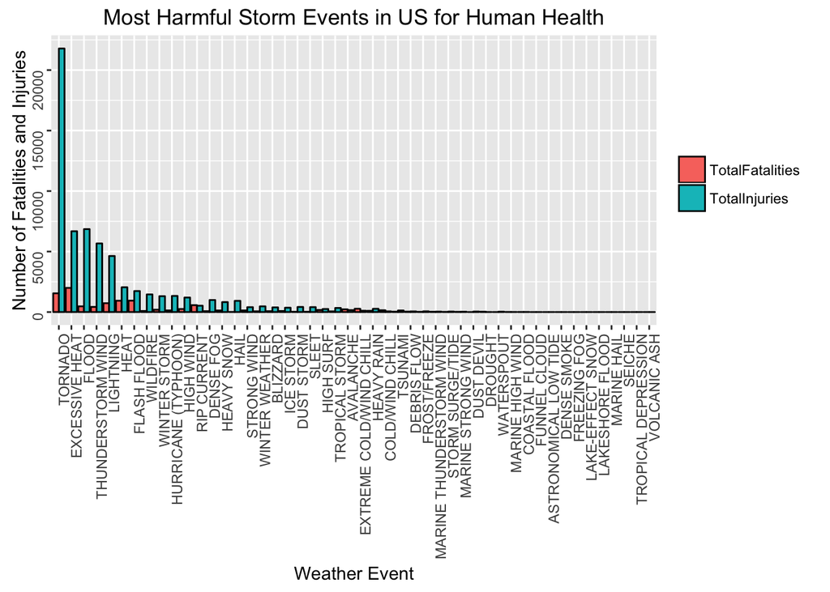

```r
print(healthPlot)
```

**Conclusion:** Tornadoes and Excessive Heat are the most damaging weather events in terms of human health, with excessive heat resulting in more fatalities and tornadoes causing more injuries. With that said, Tornadoes have a significantly larger impact to human health when the total number of injuries **and** the total number of fatalities are taken into account.

## 2. Determine which types of events have the greatest economic consequences, based on property and crop damages.

The 10 events with the greatest economic consequences, in terms of property and crop damages, are below:

** Top Ten Most Likely Events to Result in Property Damage **

```r
propertyLoss <- aggregate(plotData[, 4],by =list(plotData$EventType), FUN = "sum")
propertyLoss <- arrange(propertyLoss, desc(TotalPropertyDamage), Group.1)
colnames(propertyLoss)<-c("EventType", "TotalPropertyDamage")
head(propertyLoss, n=10)
```

```
##              EventType TotalPropertyDamage
## 1                FLOOD          144392.243
## 2  HURRICANE (TYPHOON)           85250.410
## 3     STORM SURGE/TIDE           47844.149
## 4              TORNADO           24930.505
## 5          FLASH FLOOD           15400.034
## 6                 HAIL           15287.494
## 7    THUNDERSTORM WIND            9858.303
## 8             WILDFIRE            7760.976
## 9       TROPICAL STORM            7658.336
## 10           HIGH WIND            5353.438
```

** Top Ten Most Likely Events to Result in Crop Damage **

```r
cropLoss <- aggregate(plotData[, 5],by =list(plotData$EventType), FUN = "sum")
cropLoss <- arrange(cropLoss, desc(TotalCropDamage), Group.1)
colnames(cropLoss)<-c("EventType", "TotalCropDamage")
head(cropLoss, n=10)
```

```
##                  EventType TotalCropDamage
## 1                  DROUGHT      13922.0718
## 2                    FLOOD       5686.6245
## 3      HURRICANE (TYPHOON)       5515.6178
## 4                     HAIL       2635.0100
## 5             FROST/FREEZE       1802.1410
## 6              FLASH FLOOD       1353.9900
## 7  EXTREME COLD/WIND CHILL       1329.5230
## 8        THUNDERSTORM WIND       1111.5285
## 9               HEAVY RAIN        730.1528
## 10          TROPICAL STORM        693.8860
```

The extent to which events have caused economic harm can also be seen in the below plot.

```r
economicPlotData <- select (plotData, EventType, TotalPropertyDamage, TotalCropDamage)
economicPlotData<- economicPlotData[order(economicPlotData$TotalPropertyDamage,decreasing = TRUE),]

##Melt the Dataset on Event Type
economicDataMelt <- melt(economicPlotData, id.vars = "EventType")

## Plot Number of Fatalities and Number of Injuries Associated with Each Event Type on A Single Plot Using GGPLOT2.
economicPlot <- ggplot(economicDataMelt, aes(x=reorder(EventType, -value),y=value))
economicPlot <- economicPlot + geom_bar(stat = "identity",aes(fill = variable),position = "dodge", color = "black")
economicPlot <- economicPlot+ labs(y = "Crop and Property Damage in Millions of USD", x = "Weather Event", title = "Economic Cost of Storm Events in the US")
economicPlot = economicPlot + theme(axis.text = element_text(angle =90, hjust=1))
economicPlot = economicPlot + theme(legend.title=element_blank())
```

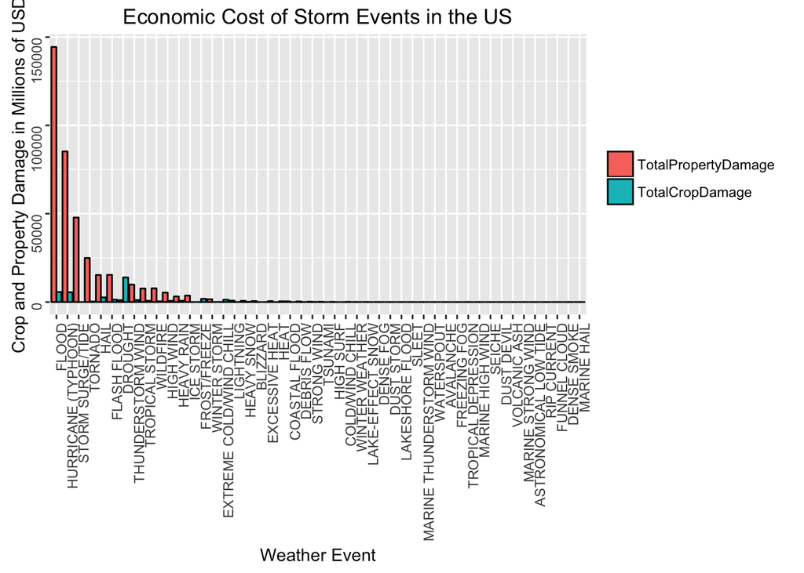

```r
print(economicPlot)
```

**Conclusion:** Floods and hurricanes are the most damaging weather events in terms of economic consequences, causing the most total damage and the most property damage. However, droughts have the most severe economic impact in terms of damages to crops alone.

### Notes Regarding the Environment Used to Conduct this Analysis:

Operating System: OSX El Capitan Version 10.11.4 Processor: 2.8 GHz quad-core Intel Core i7 Memory: 16GB of 1600 MHz DDR3L onboard memory Completed using RStudio Version 0.99.491

### Links to Supplementary Materials:

- [Github Repo](https://github.com/hilarycondon/RepData_PeerAssesment2)
- [RPubs](http://rpubs.com/hilarycondon/storm-analysis)